# NON-PARAMETRIC INDIVIDUAL CLAIM RESERVING IN INSURANCE

Notebook 1 of 3: Simluating phone inusurance data

# 1 Introduction

This is the first notebook of a series of three that outlines and elaborates upon code used to replicate the central scenario in the paper of Maximilien Baudry “NON-PARAMETRIC INDIVIDUAL CLAIM RESERVING IN INSURANCE”

https://www.institutdesactuaires.com/global/gene/link.php?doc_id=11747&fg=1  
http://chaire-dami.fr/files/2016/10/Reserving-article.pdf

The second notebook details the process for creating a reserving database and the third outlines the process for creating reserves using machine learning.

Before we start we import a few pre-requisite R packages.

```r
# Importing packages
library(data.table)
library(magrittr)
library(lubridate)
library(ggplot2)
library(cowplot)
library(repr)
library(kableExtra)

# Change plot size to 4 x 3
#options(repr.plot.width=24, repr.plot.height=12)
```

# 2 Create Policy Data set

Start by simulating number of policies sold by day and by policy coverage type.

## 2.1 Policy count by date

```r
# polices sold between start 2016 to end 2017
dt_policydates <- data.table(date_UW = seq(as.Date("2016/1/1"), as.Date("2017/12/31"), "day"))

# number of policies per day follows Poisson process with mean 700 (approx 255,500 pols per annum)
dt_policydates[, ':='(policycount = rpois(.N,700),
                      date_lapse = date_UW %m+% years(1),
                      expodays = as.integer(date_UW %m+% years(1) - date_UW),
                      pol_prefix = year(date_UW)*10000 + month(date_UW)*100 + mday(date_UW))]
```

## 2.2 Policy covers by by date

Add policy coverage columns in proportions 25% Breakage, 45% Breakage and Oxidation and 30% Breakage, Oxidation and Theft.

```r
# Add columns defining Policy Covers
dt_policydates[, Cover_B := round(policycount * 0.25)]
dt_policydates[, Cover_BO := round(policycount * 0.45)]
dt_policydates[, Cover_BOT := policycount - Cover_B - Cover_BO]

kable(head(dt_policydates), "html") %>% kable_styling("striped") %>% scroll_box(width = "100%")
```

| date_UW | policycount | date_lapse | expodays | pol_prefix | Cover_B | Cover_BO | Cover_BOT |
| --- | --- | --- | --- | --- | --- | --- | --- |
| 2016-01-01 | 685 | 2017-01-01 | 366 | 20160101 | 171 | 308 | 206 |
| 2016-01-02 | 710 | 2017-01-02 | 366 | 20160102 | 178 | 320 | 212 |
| 2016-01-03 | 692 | 2017-01-03 | 366 | 20160103 | 173 | 311 | 208 |
| 2016-01-04 | 689 | 2017-01-04 | 366 | 20160104 | 172 | 310 | 207 |
| 2016-01-05 | 645 | 2017-01-05 | 366 | 20160105 | 161 | 290 | 194 |
| 2016-01-06 | 718 | 2017-01-06 | 366 | 20160106 | 180 | 323 | 215 |

## 2.3 Policy transaction file

Next create a policy transaction file 1 row per policy, with columns to indicate policy coverage details.

### 2.3.1 Policy date & number

First step is to create policy table with 1 row per policy and underwriting date.

```r
# repeat rows for each policy by UW-Date
dt_policy <- dt_policydates[rep(1:.N, policycount),c("date_UW", "pol_prefix"), with = FALSE][,pol_seq:=1:.N, by=pol_prefix]

# Create a unique policy number
dt_policy[, pol_number := as.character(pol_prefix * 10000 + pol_seq)]

kable(head(dt_policy), "html") %>% kable_styling("striped") %>% scroll_box(width = "100%")
```

| date_UW | pol_prefix | pol_seq | pol_number |
| --- | --- | --- | --- |
| 2016-01-01 | 20160101 | 1 | 201601010001 |
| 2016-01-01 | 20160101 | 2 | 201601010002 |
| 2016-01-01 | 20160101 | 3 | 201601010003 |
| 2016-01-01 | 20160101 | 4 | 201601010004 |
| 2016-01-01 | 20160101 | 5 | 201601010005 |
| 2016-01-01 | 20160101 | 6 | 201601010006 |

### 2.3.2 Policy coverage type

Can now add the coverage appropriate to each row.

```r
# set join keys
setkey(dt_policy,'date_UW')
setkey(dt_policydates,'date_UW')

# remove pol_prefix before join
dt_policydates[, pol_prefix := NULL]

# join cover from summary file (dt_policydates)
dt_policy <- dt_policy[dt_policydates]

# now create Cover field for each policy row
dt_policy[,Cover := 'BO']
dt_policy[pol_seq <= policycount- Cover_BO,Cover := 'BOT']
dt_policy[pol_seq <= Cover_B,Cover := 'B']

dt_policy[, Cover_B := as.factor(Cover)]

# remove interim calculation fields
dt_policy[, ':='(pol_prefix = NULL,
                 policycount = NULL,
                 pol_seq = NULL,
                 Cover_B = NULL,
                 Cover_BOT = NULL,
                 Cover_BO = NULL)]

# check output
kable(head(dt_policy), "html") %>% kable_styling("striped") %>% scroll_box(width = "100%")
```

| date_UW | pol_number | date_lapse | expodays | Cover |
| --- | --- | --- | --- | --- |
| 2016-01-01 | 201601010001 | 2017-01-01 | 366 | B |
| 2016-01-01 | 201601010002 | 2017-01-01 | 366 | B |
| 2016-01-01 | 201601010003 | 2017-01-01 | 366 | B |
| 2016-01-01 | 201601010004 | 2017-01-01 | 366 | B |
| 2016-01-01 | 201601010005 | 2017-01-01 | 366 | B |
| 2016-01-01 | 201601010006 | 2017-01-01 | 366 | B |

### 2.3.3 Policy Brand, Price, Model features

Now add policy brand, model and price details to the policy dataset

```r
# Add remaining policy details
dt_policy[, Brand := rep(rep(c(1,2,3,4), c(9,6,3,2)), length.out = .N)]
dt_policy[, Base_Price := rep(rep(c(600,550,300,150), c(9,6,3,2)), length.out = .N)]

# models types and model cost multipliers
for (eachBrand in unique(dt_policy$Brand)) {
  dt_policy[Brand == eachBrand, Model := rep(rep(c(3,2,1,0), c(10, 7, 2, 1)), length.out = .N)]
  dt_policy[Brand == eachBrand, Model_mult := rep(rep(c(1.15^3, 1.15^2, 1.15^1, 1.15^0), c(10, 7, 2, 1)), length.out = .N)]
}

dt_policy[, Price := ceiling (Base_Price * Model_mult)]

# check output
kable(head(dt_policy), "html") %>% kable_styling("striped") %>% scroll_box(width = "100%")
```

| date_UW | pol_number | date_lapse | expodays | Cover | Brand | Base_Price | Model | Model_mult | Price |
| --- | --- | --- | --- | --- | --- | --- | --- | --- | --- |
| 2016-01-01 | 201601010001 | 2017-01-01 | 366 | B | 1 | 600 | 3 | 1.520875 | 913 |
| 2016-01-01 | 201601010002 | 2017-01-01 | 366 | B | 1 | 600 | 3 | 1.520875 | 913 |
| 2016-01-01 | 201601010003 | 2017-01-01 | 366 | B | 1 | 600 | 3 | 1.520875 | 913 |
| 2016-01-01 | 201601010004 | 2017-01-01 | 366 | B | 1 | 600 | 3 | 1.520875 | 913 |
| 2016-01-01 | 201601010005 | 2017-01-01 | 366 | B | 1 | 600 | 3 | 1.520875 | 913 |
| 2016-01-01 | 201601010006 | 2017-01-01 | 366 | B | 1 | 600 | 3 | 1.520875 | 913 |

### 2.3.4 Tidy and save

Keep only columns of interest and save resulting policy file.

```r
# colums to keep
cols_policy <- c("pol_number",
                 "date_UW",
                 "date_lapse",
                 "Cover",
                 "Brand",
                 "Model",
                 "Price")

dt_policy <- dt_policy[, cols_policy, with = FALSE]

# check output
kable(head(dt_policy), "html") %>% kable_styling("striped") %>% scroll_box(width = "100%")
```

| pol_number | date_UW | date_lapse | Cover | Brand | Model | Price |
| --- | --- | --- | --- | --- | --- | --- |
| 201601010001 | 2016-01-01 | 2017-01-01 | B | 1 | 3 | 913 |
| 201601010002 | 2016-01-01 | 2017-01-01 | B | 1 | 3 | 913 |
| 201601010003 | 2016-01-01 | 2017-01-01 | B | 1 | 3 | 913 |
| 201601010004 | 2016-01-01 | 2017-01-01 | B | 1 | 3 | 913 |
| 201601010005 | 2016-01-01 | 2017-01-01 | B | 1 | 3 | 913 |
| 201601010006 | 2016-01-01 | 2017-01-01 | B | 1 | 3 | 913 |

```r
save(dt_policy, file = "./dt_policy.rda")
```

# 3 Create claims file

## 3.1 Sample Claims from Policies

Claim rates vary by policy coverage and type.

### 3.1.1 Breakage Claims

Start with breakages claims. Sample from policies data set to create claims.

```r
# All policies have breakage cover
# claims uniformly sampled from policies
claim <- sample(nrow(dt_policy), size = floor(nrow(dt_policy) * 0.15))

# Claim serverity multiplier sampled from beta distn
dt_claim <- data.table(pol_number = dt_policy[claim, pol_number],
                       claim_type = 'B',
                       claim_count = 1,
                       claim_sev = rbeta(length(claim), 2,5))

# check output
kable(head(dt_claim), "html") %>% kable_styling("striped") %>% scroll_box(width = "100%")
```

| pol_number | claim_type | claim_count | claim_sev |
| --- | --- | --- | --- |
| 201704270513 | B | 1 | 0.5954740 |
| 201606030176 | B | 1 | 0.4772005 |
| 201710190639 | B | 1 | 0.3951353 |
| 201708130681 | B | 1 | 0.1170631 |
| 201612080625 | B | 1 | 0.3190475 |
| 201608250281 | B | 1 | 0.2584914 |

### 3.1.2 Oxidation Claims

```r
# identify all policies with Oxidation cover
cov <- which(dt_policy$Cover != 'B')

# sample claims from policies with cover
claim <- sample(cov, size = floor(length(cov) * 0.05))

# add claims to table
dt_claim <- rbind(dt_claim,
                  data.table(pol_number = dt_policy[claim, pol_number],
                             claim_type = 'O',
                             claim_count = 1,
                             claim_sev = rbeta(length(claim), 5,3)))

# check output
kable(head(dt_claim), "html") %>% kable_styling("striped") %>% scroll_box(width = "100%")
```

| pol_number | claim_type | claim_count | claim_sev |
| --- | --- | --- | --- |
| 201704270513 | B | 1 | 0.5954740 |
| 201606030176 | B | 1 | 0.4772005 |
| 201710190639 | B | 1 | 0.3951353 |
| 201708130681 | B | 1 | 0.1170631 |
| 201612080625 | B | 1 | 0.3190475 |
| 201608250281 | B | 1 | 0.2584914 |

### 3.1.3 Theft Claims

In the original paper the distribution for Theft severity claims is stated to be Beta(alpha = 5, beta = 0.5).

```r
# identify all policies with Theft cover
# for Theft claim frequency varies by Brand
# So need to consider each in turn...

for(myModel in 0:3) {

    cov <- which(dt_policy$Cover == 'BOT' & dt_policy$Model == myModel)
    claim <- sample(cov, size = floor(length(cov) * 0.05*(1 + myModel)))

    dt_claim <- rbind(dt_claim,
                      data.table(pol_number = dt_policy[claim, pol_number],
                                 claim_type = 'T',
                                 claim_count = 1,
                                 claim_sev = rbeta(length(claim), 5,.5)))
}

# check output
kable(head(dt_claim), "html") %>% kable_styling("striped") %>% scroll_box(width = "100%")
```

| pol_number | claim_type | claim_count | claim_sev |
| --- | --- | --- | --- |
| 201704270513 | B | 1 | 0.5954740 |
| 201606030176 | B | 1 | 0.4772005 |
| 201710190639 | B | 1 | 0.3951353 |
| 201708130681 | B | 1 | 0.1170631 |
| 201612080625 | B | 1 | 0.3190475 |
| 201608250281 | B | 1 | 0.2584914 |

```r
kable(tail(dt_claim), "html") %>% kable_styling("striped") %>% scroll_box(width = "100%")
```

| pol_number | claim_type | claim_count | claim_sev |
| --- | --- | --- | --- |
| 201706280280 | T | 1 | 0.9635726 |
| 201705190344 | T | 1 | 0.9999267 |
| 201612310290 | T | 1 | 0.9896648 |
| 201608110220 | T | 1 | 0.9979712 |
| 201612130342 | T | 1 | 0.9673484 |
| 201606070288 | T | 1 | 0.9980037 |

## 3.2 Claim dates and costs

### 3.2.1 Policy UW_date and value

Now need to add details to claims, such as policy underwritng date and phone cost. These details come from the policy table.

```r
# set join keys
setkey(dt_policy, pol_number)
setkey(dt_claim, pol_number)

#join Brand and Price from policy to claim
dt_claim[dt_policy,
         on = 'pol_number',
         ':='(date_UW = i.date_UW,
              Price = i.Price,
              Brand = i.Brand)]

# check output
kable(head(dt_claim), "html") %>% kable_styling("striped") %>% scroll_box(width = "100%")
```

| pol_number | claim_type | claim_count | claim_sev | date_UW | Price | Brand |
| --- | --- | --- | --- | --- | --- | --- |
| 201601010005 | B | 1 | 0.2911963 | 2016-01-01 | 913 | 1 |
| 201601010014 | B | 1 | 0.1961356 | 2016-01-01 | 837 | 2 |
| 201601010015 | B | 1 | 0.4451305 | 2016-01-01 | 837 | 2 |
| 201601010016 | B | 1 | 0.2068085 | 2016-01-01 | 457 | 3 |
| 201601010018 | B | 1 | 0.2705098 | 2016-01-01 | 457 | 3 |
| 201601010030 | B | 1 | 0.1943831 | 2016-01-01 | 837 | 2 |

### 3.2.2 Add simulated Claim occrrence, reporting and payment delays

Occurence delay is assumed uniform over policy exposure period. Reporting and payment delays assumed to follow Beta distribution.

```r
# use lubridate %m+% date addition operator
dt_claim[, date_lapse := date_UW %m+% years(1)]
dt_claim[, expodays := as.integer(date_lapse - date_UW)]
dt_claim[, occ_delay_days := floor(expodays * runif(.N, 0,1))]

dt_claim[ ,delay_report := floor(365 * rbeta(.N, .4, 10))]
dt_claim[ ,delay_pay := floor(10 + 40* rbeta(.N, 7,7))]

dt_claim[, date_occur := date_UW %m+% days(occ_delay_days)]
dt_claim[, date_report := date_occur %m+% days(delay_report)]
dt_claim[, date_pay := date_report %m+% days(delay_pay)]

dt_claim[, claim_cost := round(Price * claim_sev)]

# check output
kable(head(dt_claim), "html") %>% kable_styling("striped") %>% scroll_box(width = "100%")
```

| pol_number | claim_type | claim_count | claim_sev | date_UW | Price | Brand | date_lapse | expodays | occ_delay_days | delay_report | delay_pay | date_occur | date_report | date_pay | claim_cost |
| --- | --- | --- | --- | --- | --- | --- | --- | --- | --- | --- | --- | --- | --- | --- | --- |
| 201601010005 | B | 1 | 0.2911963 | 2016-01-01 | 913 | 1 | 2017-01-01 | 366 | 233 | 0 | 31 | 2016-08-21 | 2016-08-21 | 2016-09-21 | 266 |
| 201601010014 | B | 1 | 0.1961356 | 2016-01-01 | 837 | 2 | 2017-01-01 | 366 | 291 | 17 | 36 | 2016-10-18 | 2016-11-04 | 2016-12-10 | 164 |
| 201601010015 | B | 1 | 0.4451305 | 2016-01-01 | 837 | 2 | 2017-01-01 | 366 | 347 | 13 | 27 | 2016-12-13 | 2016-12-26 | 2017-01-22 | 373 |
| 201601010016 | B | 1 | 0.2068085 | 2016-01-01 | 457 | 3 | 2017-01-01 | 366 | 326 | 8 | 33 | 2016-11-22 | 2016-11-30 | 2017-01-02 | 95 |
| 201601010018 | B | 1 | 0.2705098 | 2016-01-01 | 457 | 3 | 2017-01-01 | 366 | 113 | 4 | 27 | 2016-04-23 | 2016-04-27 | 2016-05-24 | 124 |
| 201601010030 | B | 1 | 0.1943831 | 2016-01-01 | 837 | 2 | 2017-01-01 | 366 | 184 | 6 | 24 | 2016-07-03 | 2016-07-09 | 2016-08-02 | 163 |

### 3.2.3 Claim key and tidy

Simple tidying and addition of a unique claim key. Then save out the file for future use.

The original paper spoke of using a “competing hazards model” for simulating claims. I have taken this to mean that a policy can only give rise to one claim. Where the above process has simulated multiple claims against the same policy I keep only the first occuring claim.

```r
# add a unique claimkey based upon occurence date

dt_claim[, clm_prefix := year(date_occur)*10000 + month(date_occur)*100 + mday(date_occur)]
dt_claim[, clm_seq := seq_len(.N), by = clm_prefix]
dt_claim[, clm_number := as.character(clm_prefix * 10000 + clm_seq)]


# keep only first claim against policy (competing hazards)
setkeyv(dt_claim, c("pol_number", "clm_prefix"))
dt_claim[, polclm_seq := seq_len(.N), by = .(pol_number)]
dt_claim <- dt_claim[polclm_seq == 1,]

# colums to keep
cols_claim <- c("clm_number",
                "pol_number",
                "claim_type",
                "claim_count",
                "claim_sev",
                "date_occur",
                "date_report",
                "date_pay",
                "claim_cost")

dt_claim <- dt_claim[, cols_claim, with = FALSE]

# check output
kable(head(dt_claim), "html") %>% kable_styling("striped") %>% scroll_box(width = "100%")
```

| clm_number | pol_number | claim_type | claim_count | claim_sev | date_occur | date_report | date_pay | claim_cost |
| --- | --- | --- | --- | --- | --- | --- | --- | --- |
| 201608210001 | 201601010005 | B | 1 | 0.2911963 | 2016-08-21 | 2016-08-21 | 2016-09-21 | 266 |
| 201610180001 | 201601010014 | B | 1 | 0.1961356 | 2016-10-18 | 2016-11-04 | 2016-12-10 | 164 |
| 201612130001 | 201601010015 | B | 1 | 0.4451305 | 2016-12-13 | 2016-12-26 | 2017-01-22 | 373 |
| 201611220001 | 201601010016 | B | 1 | 0.2068085 | 2016-11-22 | 2016-11-30 | 2017-01-02 | 95 |
| 201604230001 | 201601010018 | B | 1 | 0.2705098 | 2016-04-23 | 2016-04-27 | 2016-05-24 | 124 |
| 201607030001 | 201601010030 | B | 1 | 0.1943831 | 2016-07-03 | 2016-07-09 | 2016-08-02 | 163 |

```r
save(dt_claim, file = "./dt_claim.rda")
```

# 4 Checking exhibits

Baudry’s paper produced a number of summary exhibits from the simulated data. Let’s recreate them to get some comfort that we have correctly recreated the data.

You can see that the severity exhbit, Chart B, is inconsistent with that presented in the original paper. The cause of that difference is unclear at the time of writing. It’s likely to be because something nearer to a Beta(alpha = 5, beta = 0.05) has been used. However using that creates other discrepancies likely to be due to issues with the competing hazards implementation. For now we note the differences and continue with the data as created here.

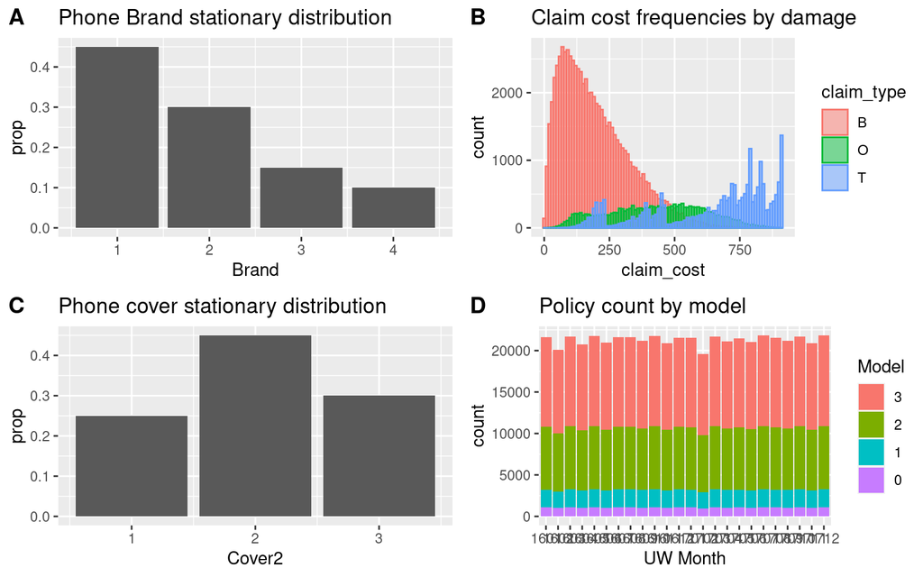

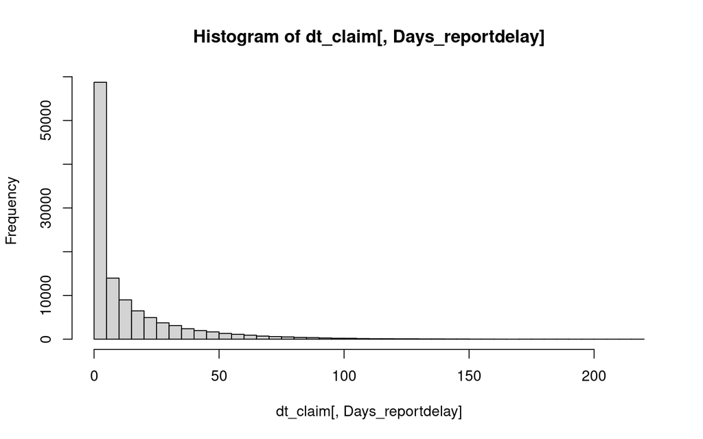

```r
dt_claim[, Days_reportdelay := as.numeric(difftime(date_report, date_occur, units="days"))]


hist(dt_claim[, Days_reportdelay],breaks = 50)
```

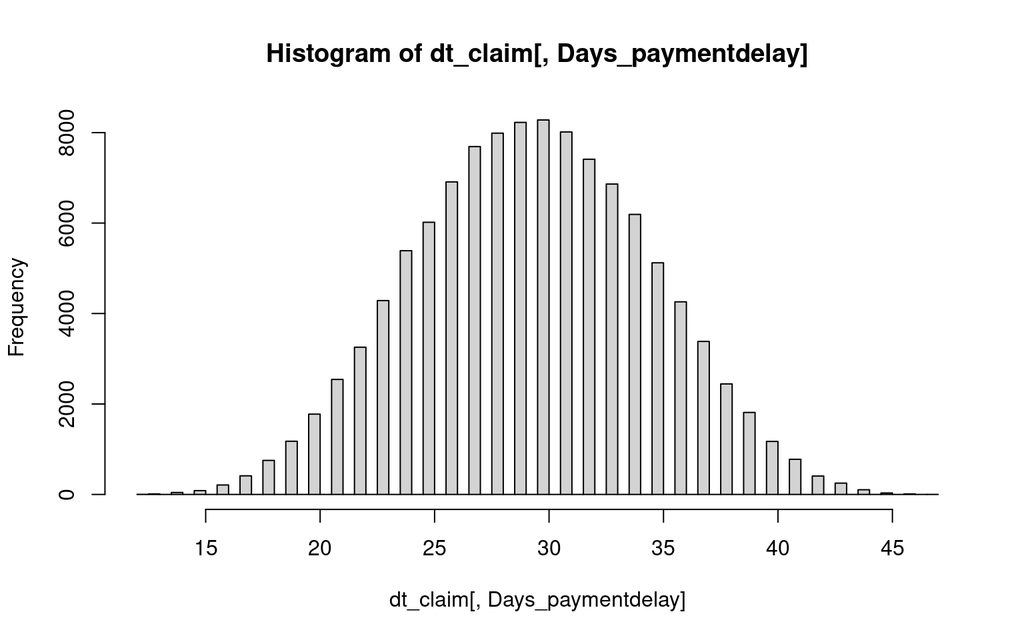

```r
dt_claim[, Days_paymentdelay := as.numeric(difftime(date_pay, date_report, units="days"))]
hist(dt_claim[, Days_paymentdelay],breaks = 60)
```

The final set of exhibits are those on slide 44. The only difference of note here is in Chart B, the Claim Rate by phone brand.

Baudry’s exhibits show Brand 1 to have a 5% higher claim frequency than other Brands. From reading the paper I can’t see why we should expect that to be the case. Claim rate varies by phone Model but Model incidence doesn’t vary by Brand. Therefore I can’t see how the Chart B equivalent could be correct given the details in the paper.

I leave the code as is noting the difference but recognising that it will not affect the wider aims of the paper.

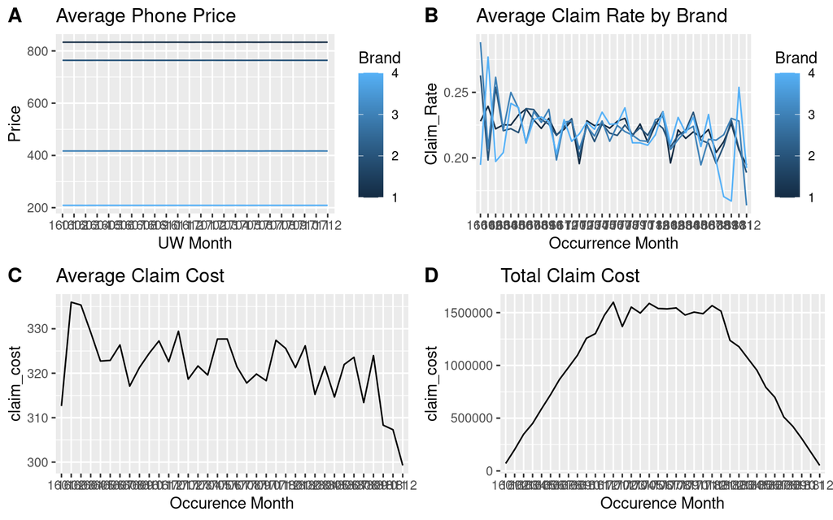

# 5 Function to create policy and claim data

The above code can be wrapped into a function which returns a list containing the policy and claim datasets.

By calling the function with a seed you can simulate policy and claim datasets.

```r
tmp <- simulate_central_scenario(1234)

kable(head(tmp$dt_claim), "html") %>% kable_styling("striped") %>% scroll_box(width = "100%")
```

[output not shown]